# Pareto/NBD Model for CLV in Stan

We can also investigate ways to remove the correlations we observed in the hyperparameters. I typically do this by plotting transformations of the parameters to find a transformation that reduces the correlation. Here we can see that the correlation is reduced by parameterizing in terms of the log shape parameter and log mean of the gamma distribution, rather than using the natural shape and scale parameterization.

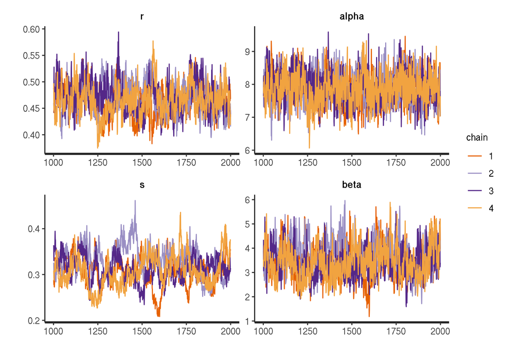

```r
p1 <- ggplot(as.data.frame(extract(results[[m]],pars=c('log_r','log_alpha','log_s','log_beta'))),
             aes(x=log_r,y=log_alpha))+geom_point(alpha=.3)+theme_bw()
p2 <- ggplot(as.data.frame(extract(results[[m]],pars=c('log_r','log_alpha','log_s','log_beta'))),
             aes(x=log_r,y=log_r-log_alpha))+geom_point(alpha=.3)+theme_bw()

p3 <- ggplot(as.data.frame(extract(results[[m]],pars=c('log_r','log_alpha','log_s','log_beta'))),
             aes(x=log_s,y=log_beta))+geom_point(alpha=.3)+theme_bw()
p4 <- ggplot(as.data.frame(extract(results[[m]],pars=c('log_r','log_alpha','log_s','log_beta'))),
             aes(x=log_s,y=log_s-log_beta))+geom_point(alpha=.3)+theme_bw()

traceplot(results[[m]],pars=c('r','alpha','s','beta'))
```

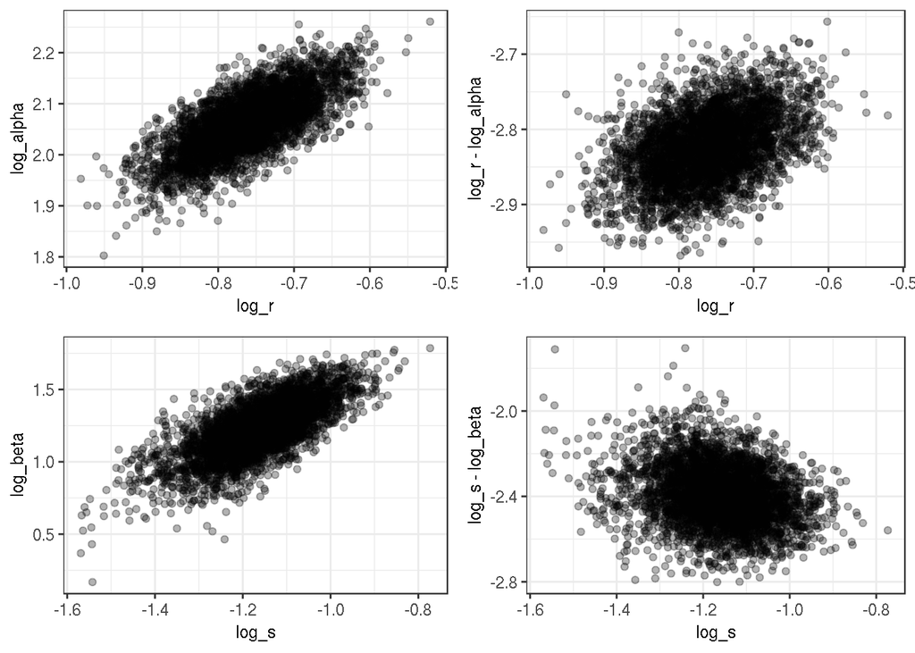

```r
grid.arrange(p1,p2,p3,p4)
```

We can incorporate this into our Stan model, and run the code:

```r
showStan("pnbd_hypermean.stan")
```

```
//Copyright 2018 Aaron Goodman <aaronjg@stanford.edu>. Licensed under the GPLv3 or later.

#include /pnbd_data.stan
parameters{
  real log_buy_a;
  real log_buy_b;
  real log_die_a;
  real log_die_b;

  vector[NC] log_lambda;
  vector[NC] log_mu;
}

transformed parameters{
  vector[NC] likelihood;
  vector[NC] lambdamu = exp(log_lambda) + exp(log_mu);
  real log_r = log_buy_a;
  real log_alpha = log_buy_a - log_buy_b;
  real log_s = log_die_b;
  real log_beta = log_die_a - log_die_b;

  real r = exp(log_r);
  real alpha = exp(log_alpha);
  real s = exp(log_s);
  real beta = exp(log_beta);

#include /pnbdlikelihoodloop.stan
}

model{
  target += NC*(r * log_alpha - lgamma(r));
  target += r*log_lambda - alpha*exp(log_lambda);
  target += NC*(s * log_beta - lgamma(s));
  target += s*log_mu - beta*exp(log_mu);

  target += log_r + log_alpha + log_s + log_beta;
  r ~ normal(1,1);
  alpha ~ normal(1,1);
  s ~ normal(1,1);
  beta ~ normal(1,1);

  target += likelihood;
}
generated quantities{
#include /pnbd_generatedquantities.stan
}
```

```r
m <- "pnbd_hypermean"
models[[m]] <- stan_model(paste0(m,".stan"))
results[[m]] <- sampling(models[[m]],stan.data,seed=123)
get_elapsed_time(results[[m]])
```

```
##         warmup sample
## chain:1 162.64  80.28
## chain:2 171.97  82.85
## chain:3 156.06  83.27
## chain:4 159.24  80.57
```

```r
print(results[[m]],
      pars=c('r','alpha','s','beta','log_lambda[1]','log_lambda[157]','log_mu[1]','log_mu[157]'),
      use_cache=FALSE)
```

```
## Inference for Stan model: pnbd_hypermean.
## 4 chains, each with iter=2000; warmup=1000; thin=1;
## post-warmup draws per chain=1000, total post-warmup draws=4000.
##
##                  mean se_mean   sd   2.5%   25%   50%   75% 97.5% n_eff Rhat
## r                0.47    0.00 0.03   0.41  0.45  0.47  0.49  0.53   167 1.01
## alpha            7.91    0.02 0.49   6.98  7.57  7.89  8.22  8.92   573 1.00
## s                0.32    0.00 0.04   0.25  0.29  0.32  0.34  0.39    71 1.03
## beta             3.54    0.05 0.70   2.21  3.06  3.54  4.00  4.92   168 1.01
## log_lambda[1]   -3.15    0.01 0.70  -4.71 -3.56 -3.07 -2.66 -2.00  4000 1.00
## log_lambda[157] -0.46    0.00 0.18  -0.84 -0.58 -0.46 -0.34 -0.12  4000 1.00
## log_mu[1]       -6.70    0.08 3.26 -15.40 -8.12 -5.88 -4.44 -2.83  1688 1.00
## log_mu[157]     -7.00    0.08 3.33 -15.84 -8.38 -6.20 -4.70 -2.98  1564 1.00
##
## Samples were drawn using NUTS(diag_e) at Tue Aug 14 18:31:21 2018.
## For each parameter, n_eff is a crude measure of effective sample size,
## and Rhat is the potential scale reduction factor on split chains (at
## convergence, Rhat=1).
```

This improves the convergence somewhat, increasing the effective sample count for $s$ and reducing the $\hat R$ for all of the population parameters. Most notably for $s$, $\hat R$ drops from 1.13 to 1.03. However, it is worth noting that not all metrics improve - the effective sample count for $\beta$ drops from 179 to 168.

We next look at using the non-centered parameterization. Because the gamma distribution is a shape/scale rather than location/scale distribution, we cannot do the full noncentered parameterization. However, we can apply the transformation on the scaling parameter, which we do below, by parameterizing `log_lambda_raw` and `log_mu_raw`, computing the desired quantities in the transformed parameter block and placing a distribution on the `log_lambda_raw` and `log_mu_raw`. The full model is below. Note the significantly simplified expressions on line 29-32 using this parameterization.

```r
showStan("pnbd_scale_adjust.stan")
```

```
//Copyright 2018 Aaron Goodman <aaronjg@stanford.edu>. Licensed under the GPLv3 or later.

#include /pnbd_data.stan
parameters{

  real log_buy_a;
  real log_buy_b;
  real log_die_a;
  real log_die_b;

  vector[NC] log_lambda_raw;
  vector[NC] log_mu_raw;
}

transformed parameters{
  vector[NC] likelihood;

  real log_r = log_buy_a;
  real log_alpha = log_buy_a - log_buy_b;
  real log_s = log_die_b;
  real log_beta = log_die_a - log_die_b;

  real r = exp(log_r);
  real alpha = exp(log_alpha);
  real s = exp(log_s);
  real beta = exp(log_beta);

  vector[NC] log_lambda = log_lambda_raw - log_alpha;
  vector[NC] log_mu = log_mu_raw - log_beta;

  vector[NC] lambdamu = exp(log_lambda) + exp(log_mu);

#include /pnbdlikelihoodloop.stan
}

model{
  target += -NC*lgamma(r);
  target += r*log_lambda_raw - exp(log_lambda_raw);
  target += -NC*lgamma(s);
  target += s*log_mu_raw - exp(log_mu_raw);


  target += log_r + log_alpha + log_s + log_beta;
  r ~ normal(1,1);
  alpha ~ normal(1,1);
  s ~ normal(1,1);
  beta ~ normal(1,1);

  target += likelihood;
}
generated quantities{
#include /pnbd_generatedquantities.stan
}
```

```r
m <- "pnbd_scale_adjust"
models[[m]] <- stan_model(paste0(m,".stan"))
results[[m]] <- sampling(models[[m]],stan.data,seed=123)
get_elapsed_time(results[[m]])
```

```
##         warmup sample
## chain:1 153.65  86.43
## chain:2 159.70  85.50
## chain:3 158.37  85.94
## chain:4 160.14  85.94
```

```r
print(results[[m]],
      pars=c('r','alpha','s','beta','log_lambda[1]','log_lambda[157]','log_mu[1]','log_mu[157]'),
      use_cache=FALSE)
```

```
## Inference for Stan model: pnbd_scale_adjust.
## 4 chains, each with iter=2000; warmup=1000; thin=1;
## post-warmup draws per chain=1000, total post-warmup draws=4000.
##
##                  mean se_mean   sd   2.5%   25%   50%   75% 97.5% n_eff Rhat
## r                0.47    0.00 0.03   0.42  0.45  0.47  0.49  0.53   143 1.04
## alpha            7.91    0.03 0.47   7.01  7.59  7.90  8.24  8.86   248 1.02
## s                0.32    0.01 0.04   0.24  0.29  0.32  0.34  0.39    26 1.17
## beta             3.49    0.11 0.70   2.21  2.99  3.46  3.94  4.95    44 1.09
## log_lambda[1]   -3.15    0.01 0.72  -4.72 -3.59 -3.08 -2.64 -1.98  4000 1.00
## log_lambda[157] -0.46    0.00 0.19  -0.84 -0.59 -0.45 -0.33 -0.11  4000 1.00
## log_mu[1]       -6.91    0.09 3.54 -16.13 -8.27 -6.01 -4.48 -2.78  1536 1.00
## log_mu[157]     -7.04    0.07 3.33 -15.83 -8.50 -6.19 -4.68 -3.05  2019 1.00
##
## Samples were drawn using NUTS(diag_e) at Tue Aug 14 18:38:34 2018.
## For each parameter, n_eff is a crude measure of effective sample size,
## and Rhat is the potential scale reduction factor on split chains (at
## convergence, Rhat=1).
```

This parameterization seems to do notably worse than the centered parameterization. All of $\hat R$ and effective sample counts for the population parameters get worse. However, it appears that the inference of some of the individual-level attrition parameters improve.

Perhaps another transformation of the parameters will help. Rather than just using the scale transformation, we will use the first two moments of the ExpGamma distribution to reparameterize the distribution of the latent parameters. We have

$E( \log \lambda | r, \alpha ) = \psi(r) - \log \alpha$ and $\mbox{Var}(\log \lambda | r, \alpha ) = \psi_1 (r)$ where $\psi$ and $\psi_1$ are the digamma and trigamma functions, respectively.

```r
showStan("pnbd_mean_var_adjust.stan")
```

```
//Copyright 2018 Aaron Goodman <aaronjg@stanford.edu>. Licensed under the GPLv3 or later.

#include /pnbd_data.stan
parameters{
  real log_buy_a;
  real log_buy_b;
  real log_die_a;
  real log_die_b;


  vector[NC] log_lambda_raw;
  vector[NC] log_mu_raw;
}

transformed parameters{
  vector[NC] likelihood;

  real log_r = log_buy_a;
  real log_alpha = log_buy_a - log_buy_b;
  real log_s = log_die_b;
  real log_beta = log_die_a - log_die_b;

  real r = exp(log_r);
  real alpha = exp(log_alpha);
  real s = exp(log_s);
  real beta = exp(log_beta);

  real tgr = trigamma(r);
  vector[NC] log_lambda = log_lambda_raw*tgr + digamma(r) - log_alpha;
  real tgs = trigamma(s);
  vector[NC] log_mu = log_mu_raw*tgs + digamma(s) - log_beta;

  vector[NC] lambdamu = exp(log_lambda) + exp(log_mu);
#include /pnbdlikelihoodloop.stan
}

model{
  target += NC * log(fabs(tgr));
  target += NC * log(fabs(tgs));

  target += NC*(r * log_alpha - lgamma(r));
  target += r*log_lambda - alpha*exp(log_lambda);
  target += NC*(s * log_beta - lgamma(s));
  target += s*log_mu - beta*exp(log_mu);

  target += log_r + log_alpha + log_s + log_beta;
  r ~ normal(1,1);
  alpha ~ normal(1,1);
  s ~ normal(1,1);
  beta ~ normal(1,1);

  target += likelihood;
}
generated quantities{
#include /pnbd_generatedquantities.stan
}
```

```r
m <- "pnbd_mean_var_adjust"
models[[m]] <- stan_model(paste0(m,".stan"))
results[[m]] <- sampling(models[[m]],stan.data,seed=123)
get_elapsed_time(results[[m]])
```

```
##         warmup sample
## chain:1 150.47  97.98
## chain:2 150.80  99.46
## chain:3 136.00  96.55
## chain:4 157.67  96.70
```

```r
print(results[[m]],
      pars=c('r','alpha','s','beta','log_lambda[1]','log_lambda[157]','log_mu[1]','log_mu[157]'),
      use_cache=FALSE)
```

```
## Inference for Stan model: pnbd_mean_var_adjust.
## 4 chains, each with iter=2000; warmup=1000; thin=1;
## post-warmup draws per chain=1000, total post-warmup draws=4000.
##
##                  mean se_mean   sd   2.5%   25%   50%   75% 97.5% n_eff Rhat
## r                0.47    0.00 0.03   0.42  0.45  0.47  0.49  0.53    45 1.09
## alpha            7.92    0.06 0.48   6.97  7.60  7.92  8.26  8.86    77 1.05
## s                0.32    0.01 0.04   0.25  0.29  0.32  0.34  0.39    32 1.12
## beta             3.52    0.10 0.74   2.26  2.97  3.46  4.00  5.13    53 1.06
## log_lambda[1]   -3.14    0.01 0.70  -4.69 -3.56 -3.07 -2.65 -1.98  4000 1.00
## log_lambda[157] -0.46    0.00 0.19  -0.85 -0.58 -0.45 -0.34 -0.12  4000 1.00
## log_mu[1]       -6.80    0.10 3.48 -15.82 -8.17 -5.91 -4.47 -2.75  1244 1.01
## log_mu[157]     -6.89    0.08 3.18 -14.99 -8.23 -6.08 -4.69 -3.01  1461 1.00
##
## Samples were drawn using NUTS(diag_e) at Tue Aug 14 18:46:46 2018.
## For each parameter, n_eff is a crude measure of effective sample size,
## and Rhat is the potential scale reduction factor on split chains (at
## convergence, Rhat=1).
```

It appears that this transformation is just as bad as the previous. While the inference for the attrition parameters has improved somewhat, the performance for the purchase rate parameters has dropped.

## Conclusion

We looked at several reparameterizations of the Pareto/NBD model. The speed of the model was improved by about 20% by manually implementing the positive constraints on the parameters and avoiding unneeded transformations between the constrained and unconstrained space. Further improvements were gained by parameterizing the gamma distribution in terms of it’s shape parameter and mean, rather than shape and scale. Attempts to use a non-centered parameterization did not add further improvements to the model.